# Studying eviction-related variables and their relevance with COVID19 statistics

## Determining the “optimal” range of k

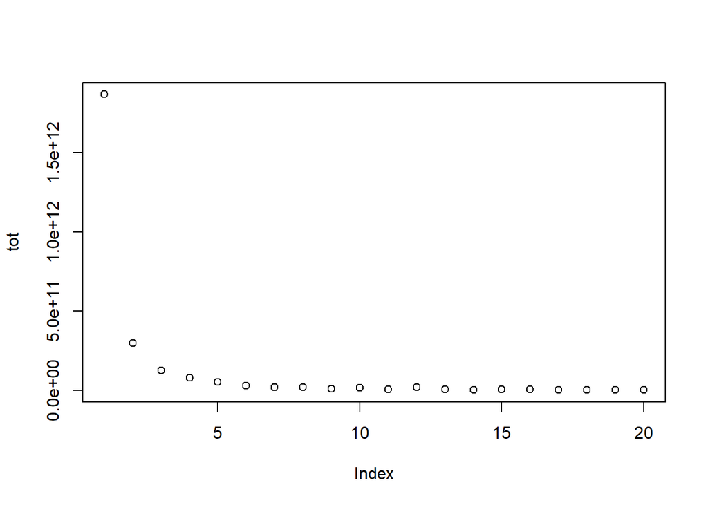

```r
# Let's make a graph showing k vs the total within cluster variation
tot <- NULL
for(i in 1:20){
 km <- kmeans(km.covid %>% dplyr::select(-State, -levels),
              i)
 tot[i] <- km$tot.withinss/i #averaging by the # of clusters
}
plot(tot) #k between 3 and 5 seems reasonable
```

Let’s explore data when k = 2, 4, *and* 6, and see if maybe a value greater than 4 would provide a better clustering than 4 or 2:

```r
km.scaled <- scale(km.covid %>%
                         dplyr::select(-State, -levels))
km.scaled_2 <- kmeans(km.scaled, 2)
km.scaled_4 <- kmeans(km.scaled, 4)
km.scaled_6 <- kmeans(km.scaled, 6)
km.scaled_2$centers
```

```
##   poverty-rate renter-occupied-households pct-renter-occupied
## 1   -0.6708387                  1.4429261           1.0991644
## 2    0.1636192                 -0.3519332          -0.2680889
##   median-gross-rent median-household-income median-property-value
## 1         1.6575033               1.4903277             1.5942448
## 2        -0.4042691              -0.3634945            -0.3888402
##   rent-burden  pct-white   pct-af-am pct-hispanic  pct-am-ind  pct-asian
## 1   0.7652106 -0.7094592  0.34323210   0.28693779 -0.39259653  1.0452630
## 2  -0.1866367  0.1730388 -0.08371515  -0.06998483  0.09575525 -0.2549422
##    pct-nh-pi pct-multiple  pct-other eviction-filings covidCases
## 1  0.5641097    0.5560995  1.4087911        1.0181066   1.550509
## 2 -0.1375877   -0.1356340 -0.3436076       -0.2483187  -0.378173
##   covidDeaths population covidCases_greater_US covidDeaths_greater_US
## 1   1.4232602  1.5423991             1.3181641              0.6619762
## 2  -0.3471366 -0.3761949            -0.3215034             -0.1614576
```

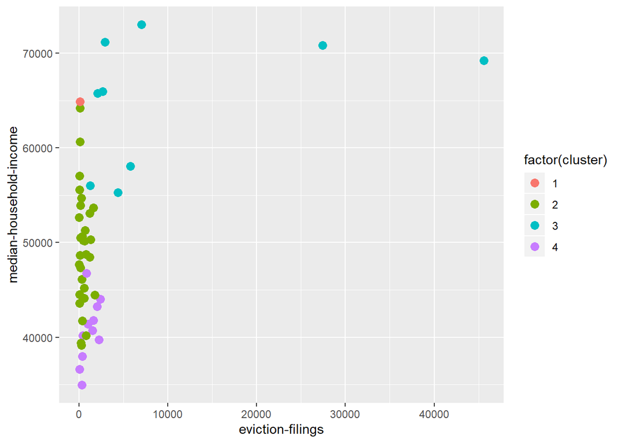

```r
km.covid %>%
  mutate(cluster = km.scaled_4$cluster) %>%
  ggplot(aes(x = `eviction-filings`,
             y = `median-household-income`)) +
  geom_point(aes(color = factor(cluster)),
             size = 3)
```

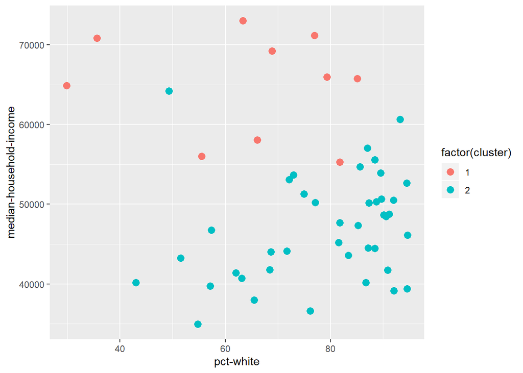

```r
km.covid %>%
  mutate(cluster = km.scaled_2$cluster) %>%
  ggplot(aes(x = `pct-white`,
             y = `median-household-income`)) +
  geom_point(aes(color = factor(cluster)),
             size = 3)
```

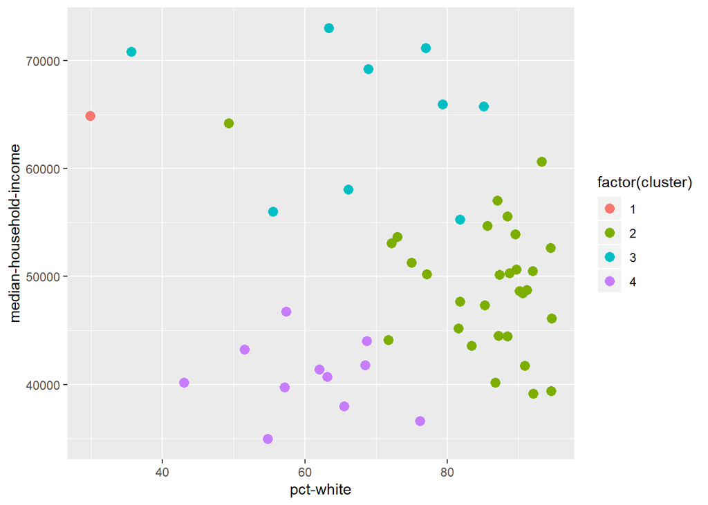

```r
km.covid %>%
  mutate(cluster = km.scaled_4$cluster) %>%
  ggplot(aes(x = `pct-white`,
             y = `median-household-income`)) +
  geom_point(aes(color = factor(cluster)),
             size = 3)
```

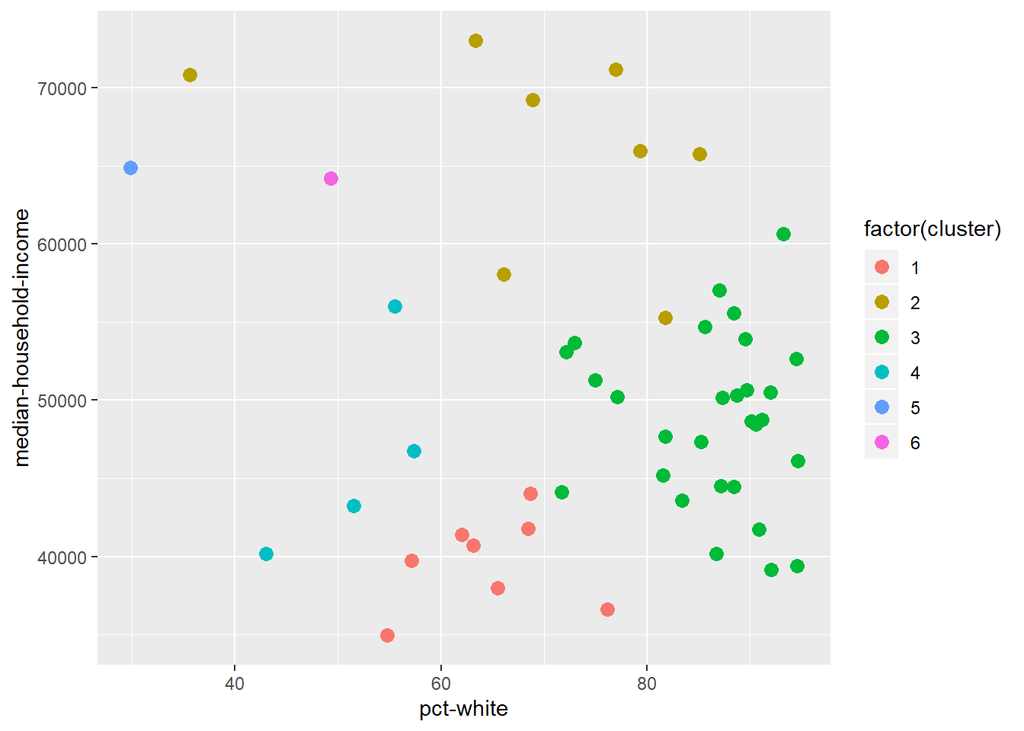

```r
km.covid %>%
  mutate(cluster = km.scaled_6$cluster) %>%
  ggplot(aes(x = `pct-white`,
             y = `median-household-income`)) +
  geom_point(aes(color = factor(cluster)),
             size = 3)
```

After many attempts of finding a visualization that separates data points into clear groups, we decided to graph a scatterplot of pct-white against median-household-income that seems to be the best visualization so far, compared to the first graph of median-household-income and eviction-filings as an example.

Right off the bat, looking at the last three graphs focused on pct-white and median-household-income, we can see that there is an overlap when k = 2, as tehre is a red point within the general parameter of the blue points. That overlap still exists when k = 4 and 6. Perhaps, k = 4 seems the optimal value amongst all, since there is only one overlap, while not underfitting or overfitting the data like when k = 2 and k = 6. Overall, however, we can affirm that, regardless of how high or low the k-value is, it is difficult to visually find and show a “perfect” separation of the 51 datapoints.

```r
# How well did k-means do?
table(km.scaled_2$cluster, km.covid$levels)
```

```
##
##     high case and deaths high case but low death low case
##   1                    4                       4        2
##   2                    2                       2       35
##
##     low case but high death
##   1                       0
##   2                       2
```

```r
table(km.scaled_4$cluster, km.covid$levels)
```

```
##
##     high case and deaths high case but low death low case
##   1                    0                       0        1
##   2                    1                       2       25
##   3                    4                       4        1
##   4                    1                       0       10
##
##     low case but high death
##   1                       0
##   2                       2
##   3                       0
##   4                       0
```

```r
table(km.scaled_6$cluster, km.covid$levels)
```

```
##
##     high case and deaths high case but low death low case
##   1                    1                       0        7
##   2                    4                       4        0
##   3                    1                       2       24
##   4                    0                       0        4
##   5                    0                       0        1
##   6                    0                       0        1
##
##     low case but high death
##   1                       0
##   2                       0
##   3                       2
##   4                       0
##   5                       0
##   6                       0
```

```r
 # use Euclidean distance
km.scaled_2$tot.withinss # total of Euclidean distances: how compact are my clusters?
```

```
## [1] 721.3713
```

```r
km.scaled_4$tot.withinss
```

```
## [1] 486.7905
```

```r
km.scaled_6$tot.withinss
```

```
## [1] 384.8403
```

# Overall Analysis

#1. Supervised vs Unsupervised Learning Supervised learning is beneficial in analyzing Covid-related data in short term, because it allows us to predict what regions would be expected to have high/low occurrences. This then would help healthcare or government officials to easily target and address issues in those areas.

Meanwhile, in unsupervised learning, we were focused more on how regions (e.g. counties and/or states) differentiate from each other, and what variables play a role in this process.

The practical use of combining supervised and unsupervised learning allows us to observe the characteristics of a certain area/region that would potentially influence certain levels (high or low) of outbreaks and/or deaths caused by Covid-19. For example, if we were to observe a situation with high correlation between high housing instability and covid cases (or deaths), then policy makers could approach the Covid issue by addressing what could perhaps be its root cause: housing instability and/or eviction.

#3. Unsupervised learning Firstly, PCA allows to decrease dimensionality of the data, because a single component or variable can account for multiple variables in the data. On the other hand, it can be difficult to visualize high-dimensional data, simlar to K-means clustering, as we are unable to see the individually analyze each variable. However, despite the lack of ability to visually present the data, it can give insight to what drives the dendrogram that we create.

Hierarchical clustering is geared more towards looking at the level of dissimiarility of accuracies and allows us to observe which states are more similar and different from one another. It does somewhat answer to our research question that focuses on potential relevance of socioeconomic factors like eviction rate, poverty rate, and income with covid case and death rates, but is only restricted to our assumption, including the effect of geographical proximity on clustering. Ultimately, we cannot confirm solely from hierarchical clustering. Moreover, we are limited to observing one condition of all four conditions at a time (e.g. covid case rate < US level).

With k-means clustering, not only is it hard to determine the “optimal” k, but it is also time consuming to create a “perfect” graph that shows clear clusters, espeically when k-means visualization shows organized clusters in two dimensions only and there are multiple variables we hope to observe. We observe that each k has its drawbacks, regardless of how high or low it is. More specifically, overlaps exist even when k is as low as 2, so maybe we should take that as given, or we should look for another, better technique than k-means clustering. One thing that k-means clustering has that hierarchical clustering doesn’t, however, is that it allows us to look at the dataset more holistically, that is, with all four cases with covid cases and deaths.

Overall, when it comes to answering our research questions and exploring our main point of relationships between eviction- and demographics- variables and covid-related data, some combination of PCA hierarchical clustering seem to be the best route to explore the data. The main reason behind this is that PCA allows us to analyze what drives the creation of dendrogram that presents distances of dissimilarity amongst states and shows a better visualization that what PCA does. Even though we have looked at samples of some states in this clustering method, our study serves as a sample of a bigger study that could be conducted for further research that looks more deeply into what determines the level of dissimilarities amongst the states besides the potential geographical proximity and other socioeconomic factors behind eviction filings.

*References* * Unsupervised https://towardsdatascience.com/understanding-the-bias-variance-tradeoff-165e6942b229 https://towardsdatascience.com/ensemble-methods-bagging-boosting-and-stacking-c9214a10a205 https://towardsdatascience.com/why-random-forest-is-my-favorite-machine-learning-model-b97651fa3706

*Supervised Ward’s method https://www.stat.cmu.edu/~cshalizi/350/lectures/08/lecture-08.pdf

fviz_cluster https://uc-r.github.io/hc_clustering https://stats.stackexchange.com/questions/263374/clusters-and-data-visualisation-in-r